# Phonetic Transfer analysis with non-z-score-normalized data

Auromita

7/29/2022

Load packages and data, create dataframe.

(note: file paths relative to project root folder (phonetic_transfer))

Gender normalizing the raw (non-z-score normalized) data

```r
gender_normalized <- with(df_time, normLobanov(cbind(f1,f2), group=gender))

df_gender_time <- df_time %>%
  select(!c(f1,f2)) %>%
  mutate(f1 = gender_normalized$f1,
         f2 = gender_normalized$f2)

rm(gender_normalized)
```

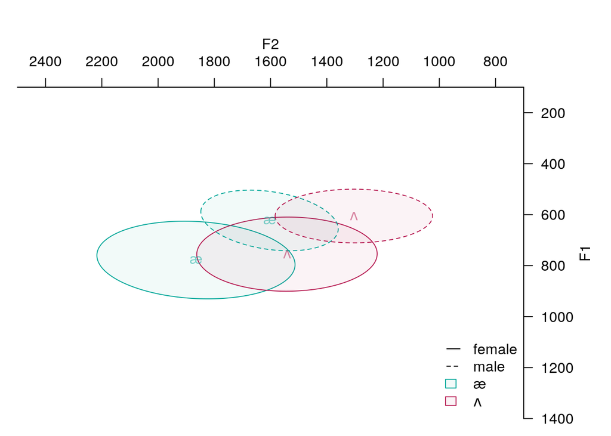

```r
# Plots before gender normalization:

xlim = c(2500, 700)
ylim = c(1400, 100)

with(df_time, plotVowels(f1, f2, vowel, group = gender,
                               plot.tokens = F, plot.means = TRUE , pch.tokens = vowel, pch.means = vowel,
                               var.col.by = vowel, var.sty.by = gender,
                               cex.tokens = 0.8, cex.means = 1, alpha.means = 0.5,alpha.tokens = 0.3,
                               ellipse.line = T,  ellipse.fill = T,
                               poly.line = F, poly.order = c("\\ae","\\vt"),
                               xlim = xlim, ylim = ylim,
                               legend.kwd = "bottomright", legend.args = gender,
                               fill.opacity = 0.05, pretty = TRUE))
```

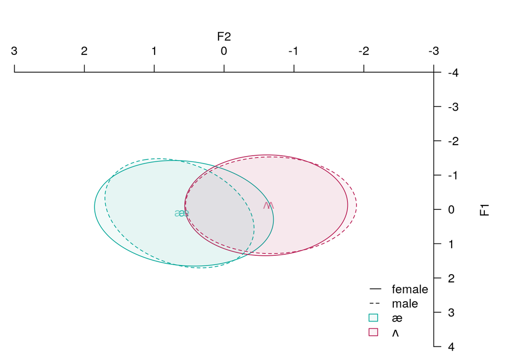

```r
# Plots after gender normalization:

xlim = c(3, -3)
ylim = c(4, -4)

with(df_gender_time, plotVowels(f1, f2, vowel, group = gender,
                               plot.tokens = F, plot.means = TRUE , pch.tokens = vowel, pch.means = vowel,
                               var.col.by = vowel, var.sty.by = gender,
                               cex.tokens = 0.8, cex.means = 1, alpha.means = 0.5,alpha.tokens = 0.3,
                               ellipse.line = T,  ellipse.fill = T,
                               poly.line = F, poly.order = c("\\ae","\\vt"),
                               xlim = xlim, ylim = ylim,
                               legend.kwd = "bottomright", legend.args = gender,
                               fill.opacity = 0.05, pretty = TRUE))
```

Fitting models to non-z-score-normalized data (only gender normalized)

```r
temp_raw <- df_gender_time %>%
  mutate(time = as.numeric(time)) %>%
  mutate(time = scale(time))
```

### F1

First, to test our first research question (L2 vowels), we fitted a model with vowel*time, and vowel*context as fixed effects. Comparing this to a null model that lacks the transfer term shows that the full model is significantly better. To confirm whether the effect of context is moderated by vowel identity, we compared a second null model that contained Context as a fixed effect, but lacked the Context*Vowel interaction. The full model was better.

```r
# full model

raw_phon_acco.model_f1 = lmer(f1 ~
                         time*vowel + vowel*context +
                         (1+context|word) + (1+context+vowel|subject),
                         data= temp_raw, REML=FALSE, control = lmerControl(optimizer = "bobyqa"))

summary(raw_phon_acco.model_f1)
```

```
## Linear mixed model fit by maximum likelihood . t-tests use Satterthwaite's
##   method [lmerModLmerTest]
## Formula: f1 ~ time * vowel + vowel * context + (1 + context | word) +
##     (1 + context + vowel | subject)
##    Data: temp_raw
## Control: lmerControl(optimizer = "bobyqa")
##
##      AIC      BIC   logLik deviance df.resid
##  20864.4  20982.2 -10416.2  20832.4    11649
##
## Scaled residuals:
##     Min      1Q  Median      3Q     Max
## -9.4356 -0.5987  0.0260  0.6346 13.0424
##
## Random effects:
##  Groups   Name        Variance Std.Dev. Corr
##  word     (Intercept) 0.038201 0.19545
##           contexte    0.005478 0.07402  0.18
##  subject  (Intercept) 0.146259 0.38244
##           contexte    0.016179 0.12720  -0.08
##           vowelʌ      0.226145 0.47555  -0.42  0.08
##  Residual             0.342162 0.58495
## Number of obs: 11665, groups:  word, 20; subject, 10
##
## Fixed effects:
##                   Estimate Std. Error         df t value Pr(>|t|)
## (Intercept)      8.553e-02  1.336e-01  1.438e+01   0.640 0.532260
## time             7.111e-01  7.565e-03  1.160e+04  94.001  < 2e-16 ***
## vowelʌ          -1.010e-01  1.664e-01  1.459e+01  -0.607 0.553051
## contexte         1.872e-02  4.877e-02  1.692e+01   0.384 0.705895
## time:vowelʌ     -1.489e-01  1.084e-02  1.160e+04 -13.742  < 2e-16 ***
## vowelʌ:contexte -1.792e-01  3.880e-02  2.026e+01  -4.619 0.000161 ***
## ---
## Signif. codes:  0 '***' 0.001 '**' 0.01 '*' 0.05 '.' 0.1 ' ' 1
```

```
##
## Correlation of Fixed Effects:
```

```
##             (Intr) time   vowelʌ contxt tm:vwʌ
## time         0.000
## vowelʌ      -0.456  0.000
## contexte    -0.052  0.000  0.064
## time:vowelʌ  0.000 -0.698  0.000  0.000
## vowlʌ:cntxt  0.005  0.000 -0.009 -0.393  0.000
```

```r
# null model 1
raw_null.model = lmer(f1~
                   time*vowel +
                   (1+context|word) + (1+context+vowel|subject),
                   data= temp_raw, REML=FALSE, control = lmerControl(optimizer = "bobyqa"))

summary(raw_null.model)
```

```
## Linear mixed model fit by maximum likelihood . t-tests use Satterthwaite's
##   method [lmerModLmerTest]
## Formula: f1 ~ time * vowel + (1 + context | word) + (1 + context + vowel |
##     subject)
##    Data: temp_raw
## Control: lmerControl(optimizer = "bobyqa")
##
##      AIC      BIC   logLik deviance df.resid
##  20875.4  20978.5 -10423.7  20847.4    11651
##
## Scaled residuals:
##     Min      1Q  Median      3Q     Max
## -9.4551 -0.5994  0.0274  0.6342 13.0257
##
## Random effects:
##  Groups   Name        Variance Std.Dev. Corr
##  word     (Intercept) 0.03808  0.1951
##           contexte    0.01542  0.1242   0.16
##  subject  (Intercept) 0.14635  0.3826
##           contexte    0.01907  0.1381   -0.09
##           vowelʌ      0.22627  0.4757   -0.42  0.09
##  Residual             0.34210  0.5849
## Number of obs: 11665, groups:  word, 20; subject, 10
##
## Fixed effects:
##               Estimate Std. Error         df t value Pr(>|t|)
## (Intercept)  8.070e-02  1.335e-01  1.446e+01   0.605    0.555
## time         7.111e-01  7.564e-03  1.160e+04  94.010   <2e-16 ***
## vowelʌ      -9.493e-02  1.660e-01  1.464e+01  -0.572    0.576
## time:vowelʌ -1.489e-01  1.083e-02  1.160e+04 -13.743   <2e-16 ***
## ---
## Signif. codes:  0 '***' 0.001 '**' 0.01 '*' 0.05 '.' 0.1 ' ' 1
##
## Correlation of Fixed Effects:
```

```
##             (Intr) time   vowelʌ
## time         0.000
## vowelʌ      -0.455  0.000
## time:vowelʌ  0.000 -0.698  0.000
```

```r
anova(raw_phon_acco.model_f1, raw_null.model)
```

```
## Data: temp_raw
## Models:
## raw_null.model: f1 ~ time * vowel + (1 + context | word) + (1 + context + vowel | subject)
## raw_phon_acco.model_f1: f1 ~ time * vowel + vowel * context + (1 + context | word) + (1 + context + vowel | subject)
##                        npar   AIC   BIC logLik deviance  Chisq Df Pr(>Chisq)
## raw_null.model           14 20875 20978 -10424    20847
## raw_phon_acco.model_f1   16 20864 20982 -10416    20832 15.039  2  0.0005425
##
## raw_null.model
## raw_phon_acco.model_f1 ***
## ---
## Signif. codes:  0 '***' 0.001 '**' 0.01 '*' 0.05 '.' 0.1 ' ' 1
```

```r
# null model 2
raw_null.model = lmer(f1~
                   time*vowel + context +
                   (1+context|word) + (1+context+vowel|subject),
                   data= temp_raw, REML=FALSE, control = lmerControl(optimizer = "bobyqa"))

summary(raw_null.model)
```

```
## Linear mixed model fit by maximum likelihood . t-tests use Satterthwaite's
##   method [lmerModLmerTest]
## Formula: f1 ~ time * vowel + context + (1 + context | word) + (1 + context +
##     vowel | subject)
##    Data: temp_raw
## Control: lmerControl(optimizer = "bobyqa")
##
##      AIC      BIC   logLik deviance df.resid
##  20875.6  20986.1 -10422.8  20845.6    11650
##
## Scaled residuals:
##     Min      1Q  Median      3Q     Max
## -9.4571 -0.5992  0.0272  0.6338 13.0244
##
## Random effects:
##  Groups   Name        Variance Std.Dev. Corr
##  word     (Intercept) 0.03807  0.1951
##           contexte    0.01488  0.1220   0.16
##  subject  (Intercept) 0.14618  0.3823
##           contexte    0.01650  0.1285   -0.08
##           vowelʌ      0.22607  0.4755   -0.42  0.08
##  Residual             0.34210  0.5849
## Number of obs: 11665, groups:  word, 20; subject, 10
##
## Fixed effects:
##               Estimate Std. Error         df t value Pr(>|t|)
## (Intercept)  8.893e-02  1.336e-01  1.437e+01   0.666    0.516
## time         7.111e-01  7.564e-03  1.160e+04  94.010   <2e-16 ***
## vowelʌ      -1.092e-01  1.663e-01  1.458e+01  -0.657    0.522
## contexte    -6.953e-02  5.013e-02  1.770e+01  -1.387    0.183
## time:vowelʌ -1.489e-01  1.083e-02  1.160e+04 -13.743   <2e-16 ***
## ---
## Signif. codes:  0 '***' 0.001 '**' 0.01 '*' 0.05 '.' 0.1 ' ' 1
##
## Correlation of Fixed Effects:
```

```
##             (Intr) time   vowelʌ contxt
## time         0.000
## vowelʌ      -0.456  0.000
## contexte    -0.040  0.000  0.060
## time:vowelʌ  0.000 -0.698  0.000  0.000
```

```r
anova(raw_phon_acco.model_f1, raw_null.model)
```

```
## Data: temp_raw
## Models:
## raw_null.model: f1 ~ time * vowel + context + (1 + context | word) + (1 + context + vowel | subject)
## raw_phon_acco.model_f1: f1 ~ time * vowel + vowel * context + (1 + context | word) + (1 + context + vowel | subject)
##                        npar   AIC   BIC logLik deviance  Chisq Df Pr(>Chisq)
## raw_null.model           15 20876 20986 -10423    20846
## raw_phon_acco.model_f1   16 20864 20982 -10416    20832 13.215  1  0.0002777
##
## raw_null.model
## raw_phon_acco.model_f1 ***
## ---
## Signif. codes:  0 '***' 0.001 '**' 0.01 '*' 0.05 '.' 0.1 ' ' 1
```

To test the hypothesis Paradigm, we fitted a model with vowel*time and task*vowel*context as fixed effects. This three-way interaction term is significant. Comparing this model to a null model that lacks the fixed effect Task shows that the full model is better. Because Task has an independent effect on F1, and adding interactions increases model parameters, we fitted a second null model with Task as a separate fixed effect without the interaction term to test whether the interaction term is needed. However, the full model was still a better fit for the data:

```r
# full model
raw_phon_acco.model_f1 = lmer(f1 ~
                         time*vowel + task*vowel*context +
                         (1+context|word) + (1+context+vowel|subject),
                         data= temp_raw, REML=FALSE, control = lmerControl(optimizer = "bobyqa"))

summary(raw_phon_acco.model_f1)
```

```
## Linear mixed model fit by maximum likelihood . t-tests use Satterthwaite's
##   method [lmerModLmerTest]
## Formula: f1 ~ time * vowel + task * vowel * context + (1 + context | word) +
##     (1 + context + vowel | subject)
##    Data: temp_raw
## Control: lmerControl(optimizer = "bobyqa")
##
##      AIC      BIC   logLik deviance df.resid
##  20351.4  20498.7 -10155.7  20311.4    11645
##
## Scaled residuals:
##     Min      1Q  Median      3Q     Max
## -9.4360 -0.6107  0.0367  0.6386 13.1156
##
## Random effects:
##  Groups   Name        Variance Std.Dev. Corr
##  word     (Intercept) 0.038607 0.19649
##           contexte    0.005931 0.07701  0.10
##  subject  (Intercept) 0.146237 0.38241
##           contexte    0.016162 0.12713  -0.09
##           vowelʌ      0.226206 0.47561  -0.42  0.08
##  Residual             0.327102 0.57193
## Number of obs: 11665, groups:  word, 20; subject, 10
##
## Fixed effects:
##                         Estimate Std. Error         df t value Pr(>|t|)
## (Intercept)           -3.622e-02  1.341e-01  1.458e+01  -0.270 0.790810
## time                   7.111e-01  7.396e-03  1.160e+04  96.141  < 2e-16 ***
## vowelʌ                -1.168e-01  1.669e-01  1.480e+01  -0.700 0.495070
## tasks                  2.471e-01  2.092e-02  1.160e+04  11.811  < 2e-16 ***
## contexte              -8.154e-03  5.128e-02  2.059e+01  -0.159 0.875216
## time:vowelʌ           -1.489e-01  1.060e-02  1.160e+04 -14.055  < 2e-16 ***
## vowelʌ:tasks           1.101e-03  3.028e-02  1.151e+04   0.036 0.971000
## tasks:contexte         5.825e-02  2.959e-02  1.160e+04   1.969 0.049004 *
## vowelʌ:contexte       -1.077e-01  4.559e-02  3.364e+01  -2.362 0.024113 *
## vowelʌ:tasks:contexte -1.457e-01  4.273e-02  1.121e+04  -3.409 0.000654 ***
## ---
## Signif. codes:  0 '***' 0.001 '**' 0.01 '*' 0.05 '.' 0.1 ' ' 1
```

```
##
## Correlation of Fixed Effects:
```

```
##             (Intr) time   vowelʌ tasks  contxt tm:vwʌ vwlʌ:t tsks:c vwlʌ:c
## time         0.000
## vowelʌ      -0.456  0.000
## tasks       -0.075  0.000  0.058
## contexte    -0.080  0.000  0.082  0.204
## time:vowelʌ  0.000 -0.698  0.000  0.000  0.000
## vowelʌ:tsks  0.047  0.000 -0.084 -0.691 -0.141  0.000
## tasks:cntxt  0.055  0.000 -0.044 -0.707 -0.287  0.000  0.488
## vowlʌ:cntxt  0.031  0.000 -0.054 -0.230 -0.427  0.000  0.344  0.321
## vwlʌ:tsks:c -0.034  0.000  0.059  0.490  0.199  0.000 -0.705 -0.692 -0.488
```

```r
# null model 1
raw_null.model = lmer(f1~
                   time*vowel + vowel*context +
                   (1+context|word) + (1+context+vowel|subject),
                   data= temp_raw, REML=FALSE, control = lmerControl(optimizer = "bobyqa"))

summary(raw_null.model)
```

```
## Linear mixed model fit by maximum likelihood . t-tests use Satterthwaite's
##   method [lmerModLmerTest]
## Formula: f1 ~ time * vowel + vowel * context + (1 + context | word) +
##     (1 + context + vowel | subject)
##    Data: temp_raw
## Control: lmerControl(optimizer = "bobyqa")
##
##      AIC      BIC   logLik deviance df.resid
##  20864.4  20982.2 -10416.2  20832.4    11649
##
## Scaled residuals:
##     Min      1Q  Median      3Q     Max
## -9.4356 -0.5987  0.0260  0.6346 13.0424
##
## Random effects:
##  Groups   Name        Variance Std.Dev. Corr
##  word     (Intercept) 0.038201 0.19545
##           contexte    0.005478 0.07402  0.18
##  subject  (Intercept) 0.146259 0.38244
##           contexte    0.016179 0.12720  -0.08
##           vowelʌ      0.226145 0.47555  -0.42  0.08
##  Residual             0.342162 0.58495
## Number of obs: 11665, groups:  word, 20; subject, 10
##
## Fixed effects:
##                   Estimate Std. Error         df t value Pr(>|t|)
## (Intercept)      8.553e-02  1.336e-01  1.438e+01   0.640 0.532260
## time             7.111e-01  7.565e-03  1.160e+04  94.001  < 2e-16 ***
## vowelʌ          -1.010e-01  1.664e-01  1.459e+01  -0.607 0.553051
## contexte         1.872e-02  4.877e-02  1.692e+01   0.384 0.705895
## time:vowelʌ     -1.489e-01  1.084e-02  1.160e+04 -13.742  < 2e-16 ***
## vowelʌ:contexte -1.792e-01  3.880e-02  2.026e+01  -4.619 0.000161 ***
## ---
## Signif. codes:  0 '***' 0.001 '**' 0.01 '*' 0.05 '.' 0.1 ' ' 1
```

```
##
## Correlation of Fixed Effects:
```

```
##             (Intr) time   vowelʌ contxt tm:vwʌ
## time         0.000
## vowelʌ      -0.456  0.000
## contexte    -0.052  0.000  0.064
## time:vowelʌ  0.000 -0.698  0.000  0.000
## vowlʌ:cntxt  0.005  0.000 -0.009 -0.393  0.000
```

```r
anova(raw_phon_acco.model_f1, raw_null.model)
```

```
## Data: temp_raw
## Models:
## raw_null.model: f1 ~ time * vowel + vowel * context + (1 + context | word) + (1 + context + vowel | subject)
## raw_phon_acco.model_f1: f1 ~ time * vowel + task * vowel * context + (1 + context | word) + (1 + context + vowel | subject)
##                        npar   AIC   BIC logLik deviance  Chisq Df Pr(>Chisq)
## raw_null.model           16 20864 20982 -10416    20832
## raw_phon_acco.model_f1   20 20351 20499 -10156    20311 521.01  4  < 2.2e-16
##
## raw_null.model
## raw_phon_acco.model_f1 ***
## ---
## Signif. codes:  0 '***' 0.001 '**' 0.01 '*' 0.05 '.' 0.1 ' ' 1
```

```r
# null model 2
raw_null.model = lmer(f1~
                   time*vowel + vowel*context + task +
                   (1+context|word) + (1+context+vowel|subject),
                   data= temp_raw, REML=FALSE, control = lmerControl(optimizer = "bobyqa"))

summary(raw_null.model)
```

```
## Linear mixed model fit by maximum likelihood . t-tests use Satterthwaite's
##   method [lmerModLmerTest]
## Formula: f1 ~ time * vowel + vowel * context + task + (1 + context | word) +
##     (1 + context + vowel | subject)
##    Data: temp_raw
## Control: lmerControl(optimizer = "bobyqa")
##
##      AIC      BIC   logLik deviance df.resid
##  20368.4  20493.5 -10167.2  20334.4    11648
##
## Scaled residuals:
##     Min      1Q  Median      3Q     Max
## -9.4287 -0.6110  0.0360  0.6392 13.1098
##
## Random effects:
##  Groups   Name        Variance Std.Dev. Corr
##  word     (Intercept) 0.038597 0.19646
##           contexte    0.005435 0.07373  0.12
##  subject  (Intercept) 0.146241 0.38241
##           contexte    0.016184 0.12722  -0.09
##           vowelʌ      0.226231 0.47564  -0.42  0.08
##  Residual             0.327784 0.57252
## Number of obs: 11665, groups:  word, 20; subject, 10
##
## Fixed effects:
##                   Estimate Std. Error         df t value Pr(>|t|)
## (Intercept)     -3.353e-02  1.338e-01  1.445e+01  -0.251  0.80565
## time             7.111e-01  7.404e-03  1.160e+04  96.041  < 2e-16 ***
## vowelʌ          -1.168e-01  1.663e-01  1.458e+01  -0.702  0.49358
## contexte         2.103e-02  4.866e-02  1.690e+01   0.432  0.67104
## tasks            2.423e-01  1.074e-02  1.161e+04  22.559  < 2e-16 ***
## time:vowelʌ     -1.489e-01  1.061e-02  1.160e+04 -14.040  < 2e-16 ***
## vowelʌ:contexte -1.847e-01  3.858e-02  2.017e+01  -4.788  0.00011 ***
## ---
## Signif. codes:  0 '***' 0.001 '**' 0.01 '*' 0.05 '.' 0.1 ' ' 1
```

```
##
## Correlation of Fixed Effects:
```

```
##             (Intr) time   vowelʌ contxt tasks  tm:vwʌ
## time         0.000
## vowelʌ      -0.455  0.000
## contexte    -0.065  0.000  0.072
## tasks       -0.039  0.000 -0.004  0.002
## time:vowelʌ  0.000 -0.698  0.000  0.000  0.000
## vowlʌ:cntxt  0.015  0.000 -0.025 -0.392 -0.006  0.000
```

```r
anova(raw_phon_acco.model_f1, raw_null.model)
```

```
## Data: temp_raw
## Models:
## raw_null.model: f1 ~ time * vowel + vowel * context + task + (1 + context | word) + (1 + context + vowel | subject)
## raw_phon_acco.model_f1: f1 ~ time * vowel + task * vowel * context + (1 + context | word) + (1 + context + vowel | subject)
##                        npar   AIC   BIC logLik deviance  Chisq Df Pr(>Chisq)
## raw_null.model           17 20368 20494 -10167    20334
## raw_phon_acco.model_f1   20 20351 20499 -10156    20311 22.975  3  4.086e-05
##
## raw_null.model
## raw_phon_acco.model_f1 ***
## ---
## Signif. codes:  0 '***' 0.001 '**' 0.01 '*' 0.05 '.' 0.1 ' ' 1
```

Because an independent effect of task on FFs is unexpected (c.f. model interpretation below), we wanted to examine if the effect might be local, i.e. decrease over time. We added a task*time interaction term to the full model, which is significant and improves model fit.

```r
# full model
raw_phon_acco.model_f1 = lmer(f1 ~
                         time*vowel + task*vowel*context + task*time +
                         (1+context|word) + (1+context+vowel|subject),
                         data= temp_raw, REML=FALSE, control = lmerControl(optimizer = "bobyqa"))

summary(raw_phon_acco.model_f1)
```

```
## Linear mixed model fit by maximum likelihood . t-tests use Satterthwaite's
##   method [lmerModLmerTest]
## Formula: f1 ~ time * vowel + task * vowel * context + task * time + (1 +
##     context | word) + (1 + context + vowel | subject)
##    Data: temp_raw
## Control: lmerControl(optimizer = "bobyqa")
##
##      AIC      BIC   logLik deviance df.resid
##  20310.9  20465.5 -10134.4  20268.9    11644
##
## Scaled residuals:
##     Min      1Q  Median      3Q     Max
## -9.4107 -0.6032  0.0309  0.6434 13.1797
##
## Random effects:
##  Groups   Name        Variance Std.Dev. Corr
##  word     (Intercept) 0.038611 0.19650
##           contexte    0.005941 0.07708  0.10
##  subject  (Intercept) 0.146242 0.38242
##           contexte    0.016166 0.12715  -0.09
##           vowelʌ      0.226209 0.47561  -0.42  0.08
##  Residual             0.325905 0.57088
## Number of obs: 11665, groups:  word, 20; subject, 10
##
## Fixed effects:
##                         Estimate Std. Error         df t value Pr(>|t|)
## (Intercept)           -3.627e-02  1.341e-01  1.458e+01  -0.271 0.790555
## time                   7.455e-01  9.077e-03  1.160e+04  82.134  < 2e-16 ***
## vowelʌ                -1.167e-01  1.669e-01  1.479e+01  -0.699 0.495282
## tasks                  2.471e-01  2.088e-02  1.160e+04  11.833  < 2e-16 ***
## contexte              -8.164e-03  5.128e-02  2.059e+01  -0.159 0.875051
## time:vowelʌ           -1.469e-01  1.058e-02  1.160e+04 -13.889  < 2e-16 ***
## vowelʌ:tasks           1.116e-03  3.023e-02  1.151e+04   0.037 0.970553
## tasks:contexte         5.824e-02  2.953e-02  1.160e+04   1.972 0.048596 *
## vowelʌ:contexte       -1.076e-01  4.557e-02  3.359e+01  -2.362 0.024132 *
## time:tasks            -6.903e-02  1.058e-02  1.160e+04  -6.525  7.1e-11 ***
## vowelʌ:tasks:contexte -1.457e-01  4.266e-02  1.121e+04  -3.416 0.000638 ***
## ---
## Signif. codes:  0 '***' 0.001 '**' 0.01 '*' 0.05 '.' 0.1 ' ' 1
```

```
##
## Correlation of Fixed Effects:
```

```
##             (Intr) time   vowelʌ tasks  contxt tm:vwʌ vwlʌ:t tsks:c vwlʌ:c
## time         0.000
## vowelʌ      -0.456  0.000
## tasks       -0.075  0.000  0.058
## contexte    -0.080  0.000  0.082  0.204
## time:vowelʌ  0.000 -0.551  0.000  0.000  0.000
## vowelʌ:tsks  0.047  0.000 -0.084 -0.691 -0.141  0.000
## tasks:cntxt  0.055  0.000 -0.044 -0.707 -0.286  0.000  0.488
## vowlʌ:cntxt  0.031  0.000 -0.054 -0.229 -0.427  0.000  0.343  0.321
## time:tasks   0.000 -0.582  0.000  0.000  0.000 -0.029  0.000  0.000  0.000
## vwlʌ:tsks:c -0.034  0.000  0.059  0.490  0.199  0.000 -0.705 -0.692 -0.488
##             tm:tsk
## time
## vowelʌ
## tasks
## contexte
## time:vowelʌ
## vowelʌ:tsks
## tasks:cntxt
## vowlʌ:cntxt
## time:tasks
## vwlʌ:tsks:c  0.000
```

```r
# null model
raw_null.model = lmer(f1~
                   time*vowel + task*vowel*context +
                   (1+context|word) + (1+context+vowel|subject),
                   data= temp_raw, REML=FALSE, control = lmerControl(optimizer = "bobyqa"))

summary(raw_null.model)
```

```
## Linear mixed model fit by maximum likelihood . t-tests use Satterthwaite's
##   method [lmerModLmerTest]
## Formula: f1 ~ time * vowel + task * vowel * context + (1 + context | word) +
##     (1 + context + vowel | subject)
##    Data: temp_raw
## Control: lmerControl(optimizer = "bobyqa")
##
##      AIC      BIC   logLik deviance df.resid
##  20351.4  20498.7 -10155.7  20311.4    11645
##
## Scaled residuals:
##     Min      1Q  Median      3Q     Max
## -9.4360 -0.6107  0.0367  0.6386 13.1156
##
## Random effects:
##  Groups   Name        Variance Std.Dev. Corr
##  word     (Intercept) 0.038607 0.19649
##           contexte    0.005931 0.07701  0.10
##  subject  (Intercept) 0.146237 0.38241
##           contexte    0.016162 0.12713  -0.09
##           vowelʌ      0.226206 0.47561  -0.42  0.08
##  Residual             0.327102 0.57193
## Number of obs: 11665, groups:  word, 20; subject, 10
##
## Fixed effects:
##                         Estimate Std. Error         df t value Pr(>|t|)
## (Intercept)           -3.622e-02  1.341e-01  1.458e+01  -0.270 0.790810
## time                   7.111e-01  7.396e-03  1.160e+04  96.141  < 2e-16 ***
## vowelʌ                -1.168e-01  1.669e-01  1.480e+01  -0.700 0.495070
## tasks                  2.471e-01  2.092e-02  1.160e+04  11.811  < 2e-16 ***
## contexte              -8.154e-03  5.128e-02  2.059e+01  -0.159 0.875216
## time:vowelʌ           -1.489e-01  1.060e-02  1.160e+04 -14.055  < 2e-16 ***
## vowelʌ:tasks           1.101e-03  3.028e-02  1.151e+04   0.036 0.971000
## tasks:contexte         5.825e-02  2.959e-02  1.160e+04   1.969 0.049004 *
## vowelʌ:contexte       -1.077e-01  4.559e-02  3.364e+01  -2.362 0.024113 *
## vowelʌ:tasks:contexte -1.457e-01  4.273e-02  1.121e+04  -3.409 0.000654 ***
## ---
## Signif. codes:  0 '***' 0.001 '**' 0.01 '*' 0.05 '.' 0.1 ' ' 1
```

```
##
## Correlation of Fixed Effects:
```

```
##             (Intr) time   vowelʌ tasks  contxt tm:vwʌ vwlʌ:t tsks:c vwlʌ:c
## time         0.000
## vowelʌ      -0.456  0.000
## tasks       -0.075  0.000  0.058
## contexte    -0.080  0.000  0.082  0.204
## time:vowelʌ  0.000 -0.698  0.000  0.000  0.000
## vowelʌ:tsks  0.047  0.000 -0.084 -0.691 -0.141  0.000
## tasks:cntxt  0.055  0.000 -0.044 -0.707 -0.287  0.000  0.488
## vowlʌ:cntxt  0.031  0.000 -0.054 -0.230 -0.427  0.000  0.344  0.321
## vwlʌ:tsks:c -0.034  0.000  0.059  0.490  0.199  0.000 -0.705 -0.692 -0.488
```

```r
anova(raw_phon_acco.model_f1, raw_null.model)
```

```
## Data: temp_raw
## Models:
## raw_null.model: f1 ~ time * vowel + task * vowel * context + (1 + context | word) + (1 + context + vowel | subject)
## raw_phon_acco.model_f1: f1 ~ time * vowel + task * vowel * context + task * time + (1 + context | word) + (1 + context + vowel | subject)
##                        npar   AIC   BIC logLik deviance  Chisq Df Pr(>Chisq)
## raw_null.model           20 20351 20499 -10156    20311
## raw_phon_acco.model_f1   21 20311 20466 -10134    20269 42.494  1   7.09e-11
##
## raw_null.model
## raw_phon_acco.model_f1 ***
## ---
## Signif. codes:  0 '***' 0.001 '**' 0.01 '*' 0.05 '.' 0.1 ' ' 1
```

Next, to examine the dynamics of transfer, we added a three-way interaction between the transfer term (vowel*context) and time. This term has a significant effect, but does not significantly improve model fit compared to a null model lacking the vowel*context*time term.

```r
# full model
raw_phon_acco.model_f1 = lmer(f1 ~
                         time*vowel + task*vowel*context + task*time + vowel*context*time +
                         (1+context|word) + (1+context+vowel|subject),
                         data= temp_raw, REML=FALSE, control = lmerControl(optimizer = "bobyqa"))

summary(raw_phon_acco.model_f1)
```

```
## Linear mixed model fit by maximum likelihood . t-tests use Satterthwaite's
##   method [lmerModLmerTest]
## Formula: f1 ~ time * vowel + task * vowel * context + task * time + vowel *
##     context * time + (1 + context | word) + (1 + context + vowel |
##     subject)
##    Data: temp_raw
## Control: lmerControl(optimizer = "bobyqa")
##
##      AIC      BIC   logLik deviance df.resid
##  20309.4  20478.8 -10131.7  20263.4    11642
##
## Scaled residuals:
##     Min      1Q  Median      3Q     Max
## -9.4286 -0.6038  0.0313  0.6418 13.1678
##
## Random effects:
##  Groups   Name        Variance Std.Dev. Corr
##  word     (Intercept) 0.038612 0.19650
##           contexte    0.005942 0.07709  0.10
##  subject  (Intercept) 0.146242 0.38242
##           contexte    0.016167 0.12715  -0.09
##           vowelʌ      0.226211 0.47562  -0.42  0.08
##  Residual             0.325751 0.57075
## Number of obs: 11665, groups:  word, 20; subject, 10
##
## Fixed effects:
##                         Estimate Std. Error         df t value Pr(>|t|)
## (Intercept)           -3.627e-02  1.341e-01  1.458e+01  -0.271 0.790522
## time                   7.329e-01  1.170e-02  1.160e+04  62.630  < 2e-16 ***
## vowelʌ                -1.167e-01  1.669e-01  1.479e+01  -0.699 0.495310
## tasks                  2.471e-01  2.088e-02  1.160e+04  11.835  < 2e-16 ***
## contexte              -8.165e-03  5.128e-02  2.059e+01  -0.159 0.875029
## time:vowelʌ           -1.222e-01  1.495e-02  1.160e+04  -8.173 3.31e-16 ***
## vowelʌ:tasks           1.118e-03  3.022e-02  1.151e+04   0.037 0.970496
## tasks:contexte         5.824e-02  2.952e-02  1.160e+04   1.973 0.048543 *
## vowelʌ:contexte       -1.076e-01  4.557e-02  3.359e+01  -2.362 0.024134 *
## time:tasks            -6.896e-02  1.058e-02  1.160e+04  -6.519 7.36e-11 ***
## time:contexte          2.526e-02  1.476e-02  1.160e+04   1.711 0.087018 .
## vowelʌ:tasks:contexte -1.457e-01  4.265e-02  1.121e+04  -3.417 0.000636 ***
## time:vowelʌ:contexte  -4.950e-02  2.115e-02  1.160e+04  -2.341 0.019247 *
## ---
## Signif. codes:  0 '***' 0.001 '**' 0.01 '*' 0.05 '.' 0.1 ' ' 1
```

```
##
## Correlation matrix not shown by default, as p = 13 > 12.
## Use print(x, correlation=TRUE)  or
##     vcov(x)        if you need it
```

```r
# null model
raw_null.model = lmer(f1~
                   time*vowel + task*vowel*context + task*time +
                   (1+context|word) + (1+context+vowel|subject),
                   data= temp_raw, REML=FALSE, control = lmerControl(optimizer = "bobyqa"))

summary(raw_null.model)
```

```
## Linear mixed model fit by maximum likelihood . t-tests use Satterthwaite's
##   method [lmerModLmerTest]
## Formula: f1 ~ time * vowel + task * vowel * context + task * time + (1 +
##     context | word) + (1 + context + vowel | subject)
##    Data: temp_raw
## Control: lmerControl(optimizer = "bobyqa")
##
##      AIC      BIC   logLik deviance df.resid
##  20310.9  20465.5 -10134.4  20268.9    11644
##
## Scaled residuals:
##     Min      1Q  Median      3Q     Max
## -9.4107 -0.6032  0.0309  0.6434 13.1797
##
## Random effects:
##  Groups   Name        Variance Std.Dev. Corr
##  word     (Intercept) 0.038611 0.19650
##           contexte    0.005941 0.07708  0.10
##  subject  (Intercept) 0.146242 0.38242
##           contexte    0.016166 0.12715  -0.09
##           vowelʌ      0.226209 0.47561  -0.42  0.08
##  Residual             0.325905 0.57088
## Number of obs: 11665, groups:  word, 20; subject, 10
##
## Fixed effects:
##                         Estimate Std. Error         df t value Pr(>|t|)
## (Intercept)           -3.627e-02  1.341e-01  1.458e+01  -0.271 0.790555
## time                   7.455e-01  9.077e-03  1.160e+04  82.134  < 2e-16 ***
## vowelʌ                -1.167e-01  1.669e-01  1.479e+01  -0.699 0.495282
## tasks                  2.471e-01  2.088e-02  1.160e+04  11.833  < 2e-16 ***
## contexte              -8.164e-03  5.128e-02  2.059e+01  -0.159 0.875051
## time:vowelʌ           -1.469e-01  1.058e-02  1.160e+04 -13.889  < 2e-16 ***
## vowelʌ:tasks           1.116e-03  3.023e-02  1.151e+04   0.037 0.970553
## tasks:contexte         5.824e-02  2.953e-02  1.160e+04   1.972 0.048596 *
## vowelʌ:contexte       -1.076e-01  4.557e-02  3.359e+01  -2.362 0.024132 *
## time:tasks            -6.903e-02  1.058e-02  1.160e+04  -6.525  7.1e-11 ***
## vowelʌ:tasks:contexte -1.457e-01  4.266e-02  1.121e+04  -3.416 0.000638 ***
## ---
## Signif. codes:  0 '***' 0.001 '**' 0.01 '*' 0.05 '.' 0.1 ' ' 1
```

```
##
## Correlation of Fixed Effects:
```

```
##             (Intr) time   vowelʌ tasks  contxt tm:vwʌ vwlʌ:t tsks:c vwlʌ:c
## time         0.000
## vowelʌ      -0.456  0.000
## tasks       -0.075  0.000  0.058
## contexte    -0.080  0.000  0.082  0.204
## time:vowelʌ  0.000 -0.551  0.000  0.000  0.000
## vowelʌ:tsks  0.047  0.000 -0.084 -0.691 -0.141  0.000
## tasks:cntxt  0.055  0.000 -0.044 -0.707 -0.286  0.000  0.488
## vowlʌ:cntxt  0.031  0.000 -0.054 -0.229 -0.427  0.000  0.343  0.321
## time:tasks   0.000 -0.582  0.000  0.000  0.000 -0.029  0.000  0.000  0.000
## vwlʌ:tsks:c -0.034  0.000  0.059  0.490  0.199  0.000 -0.705 -0.692 -0.488
##             tm:tsk
## time
## vowelʌ
## tasks
## contexte
## time:vowelʌ
## vowelʌ:tsks
## tasks:cntxt
## vowlʌ:cntxt
## time:tasks
## vwlʌ:tsks:c  0.000
```

```r
anova(raw_phon_acco.model_f1, raw_null.model)
```

```
## Data: temp_raw
## Models:
## raw_null.model: f1 ~ time * vowel + task * vowel * context + task * time + (1 + context | word) + (1 + context + vowel | subject)
## raw_phon_acco.model_f1: f1 ~ time * vowel + task * vowel * context + task * time + vowel * context * time + (1 + context | word) + (1 + context + vowel | subject)
##                        npar   AIC   BIC logLik deviance  Chisq Df Pr(>Chisq)
## raw_null.model           21 20311 20466 -10134    20269
## raw_phon_acco.model_f1   23 20309 20479 -10132    20263 5.4908  2    0.06422 .
## ---
## Signif. codes:  0 '***' 0.001 '**' 0.01 '*' 0.05 '.' 0.1 ' ' 1
```